# Final exam homework

PAPADOPOULOS CHRISTOS

2023-01-22

### Preview the data and preproccesing

```r
#import the dataset
path <- "C:/Users/Chrispdl/Desktop/edav/hw6 (1)/album.csv"

albums <- read.csv(path)
```

```r
# calculating the product of dimensions of dataframe
totalcells = prod(dim(albums))
print("Total number of cells ")
```

```
## [1] "Total number of cells "
```

```r
print(totalcells)
```

```
## [1] 34383
```

```r
# calculating the number of cells with na
missingcells = sum(is.na(albums))
print("Missing value cells")
```

```
## [1] "Missing value cells"
```

```r
print(missingcells)
```

```
## [1] 0
```

```r
#Apply na.omit() function
albums <- na.omit(albums)
```

```r
#Split the 3rd column of albums df in Year and Title
# load dplyr and tidyr library
library(dplyr)
library(tidyr)
library(tidyverse)
#split the column album to title and year
albums <-albums %>%
  separate(album,c('Year','Title'),' ',extra='merge')%>%
  mutate(Year= gsub('\\(',"",Year))%>%
  mutate(Year= gsub('\\)',"",Year))

total_albums <- nrow(albums)
total_albums
```

```
## [1] 11461
```

```r
total_artists <- length((unique(albums$artist)))
total_artists
```

```
## [1] 3692
```

```r
#split the column genre to 5 genres (primary ,secondary etc.)
library(splitstackshape)
albums<- cSplit(albums,1,sep=',',direction='wide')
albums <- albums%>%
  select(-genre_6,-genre_7,-genre_8)%>%
  arrange(Title)
```

### [1.a]τo πλήθος των album ανά genre (υπόθεση: κάθε album ανήκει μόνο στο πρωτεύον genre)

```r
count_of_albums_genre_1<- data.frame(table(albums$genre_1))%>%
  arrange(desc(Freq))
count_of_albums_genre_1
```

```
##             Var1 Freq
## 1       Pop-Rock 5062
## 2          Blues 2361
## 3           Jazz 1121
## 4            R&B  518
## 5  International  458
## 6     Electronic  429
## 7          Vocal  309
## 8      Classical  244
## 9          Latin  223
## 10          Folk  146
## 11  Stage&Screen  138
## 12        NewAge  115
## 13           Rap   82
## 14       Country   73
## 15        Reggae   50
## 16 EasyListening   41
## 17     Religious   41
## 18   Avant-Garde   38
## 19 Comedy-Spoken    9
## 20    Children's    3
```

```r
class(count_of_albums_genre_1)
```

```
## [1] "data.frame"
```

```r
top_five_genres <- count_of_albums_genre_1%>%
  slice(1:5)
top_five_genres
```

```
##            Var1 Freq
## 1      Pop-Rock 5062
## 2         Blues 2361
## 3          Jazz 1121
## 4           R&B  518
## 5 International  458
```

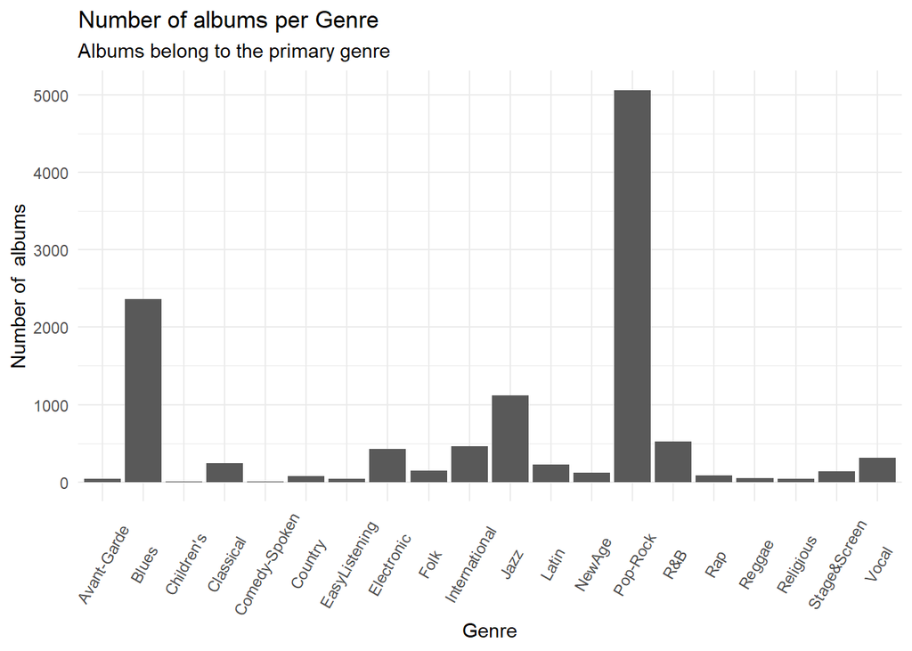

```r
plot_a <- ggplot(data= albums %>% group_by(genre_1),aes(genre_1))+geom_bar(stat = 'count')+theme_minimal()+
  labs(title='Number of albums per Genre',subtitle = 'Albums belong to the primary genre',x='Genre',y='Number of  albums')+
  theme(axis.text.x = element_text(angle = 60, vjust = 0.5, hjust=0.5))

plot_a
```

### we notice that 1 type of genre does not exist in any album as primary

### [1.b] To πλήθος των album ανά genre (υπόθεση: κάθε album ανήκει σε όλα τα genres του)

```r
# δημιουργουμε ένα dataframe  μία στήλη που έχει τύπο του genre(classical , blues κτλπ) και μία στήλη για τον αριθμό του genre(προτεύων , δευτερεύων κτλπ.)
count_of_albums <- albums%>%
  gather(genre_1,genre_2,genre_3,genre_4,genre_5,key='num_of_genre',value = 'genre')%>%
  arrange(Title)%>%
  na.omit()


#I find for each type of genre how many albums there are
count_of_albums_genre_all <- count_of_albums %>%
  group_by(genre)%>%
  summarize(frequency = n())
count_of_albums_genre_all
```

```
## # A tibble: 21 × 2
##    genre         frequency
##    <chr>             <int>
##  1 Avant-Garde         324
##  2 Blues              2951
##  3 Children's           24
##  4 Classical           774
##  5 Comedy-Spoken       105
##  6 Country             305
##  7 EasyListening       133
##  8 Electronic          659
##  9 Folk                463
## 10 Holiday              25
## # … with 11 more rows
```

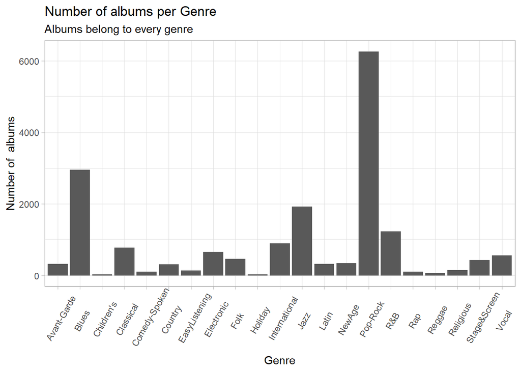

```r
plot_b <- ggplot(data= count_of_albums %>%
                   group_by(genre),aes(genre))+geom_bar(stat ='count')+theme_light()+
  labs(title='Number of albums per Genre',subtitle = 'Albums belong to every genre',x='Genre',y='Number of  albums')+
  theme(axis.text.x = element_text(angle = 60, vjust = 0.5, hjust=0.4))


plot_b
```

### [1.c] To πλήθος των artist ανά genre (υπόθεση: κάθε artist ανήκει μόνο στο πρωτεύον genre)

```r
count_of_artist_genre_1 <- albums%>%
  select(artist,genre_1)%>%           #keep only aritst and 1st genre
  distinct()%>%                      #remove duplicates cause artists have many albums
  group_by(genre_1)%>%
  summarize(count= n())

count_of_artist_genre_1
```

```
## # A tibble: 20 × 2
##    genre_1       count
##    <chr>         <int>
##  1 Avant-Garde      13
##  2 Blues           870
##  3 Children's        3
##  4 Classical       106
##  5 Comedy-Spoken     7
##  6 Country          48
##  7 EasyListening    16
##  8 Electronic      145
##  9 Folk             34
## 10 International   224
## 11 Jazz            493
## 12 Latin            97
## 13 NewAge           19
## 14 Pop-Rock       1213
## 15 R&B             185
## 16 Rap              42
## 17 Reggae           10
## 18 Religious        19
## 19 Stage&Screen     56
## 20 Vocal            93
```

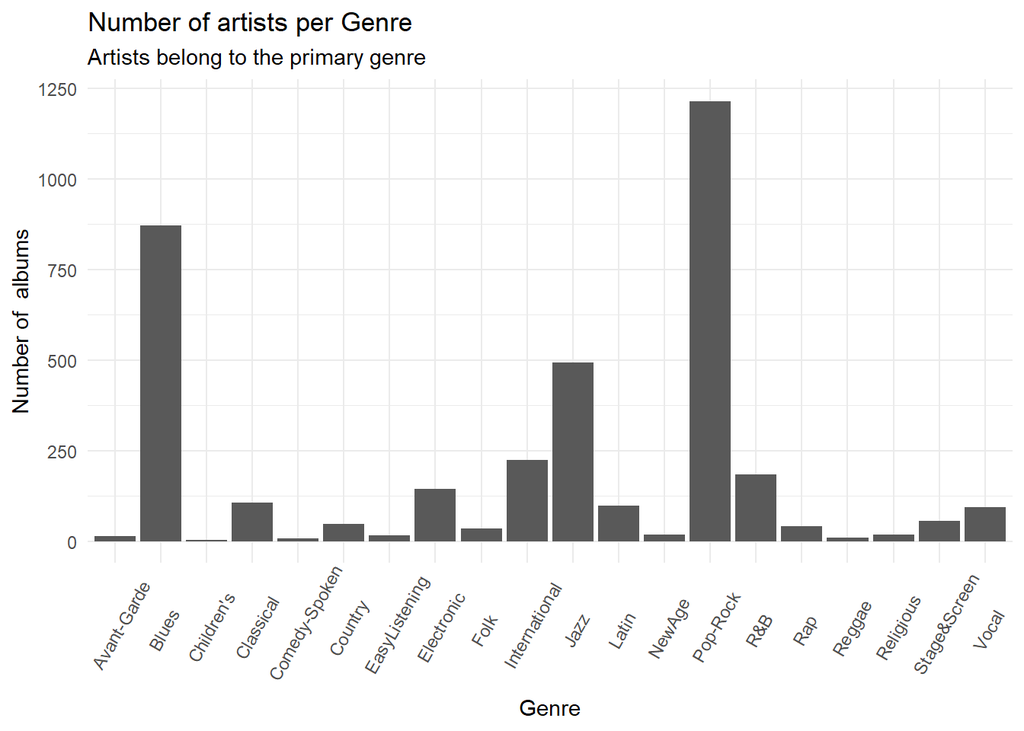

```r
plot_c <- ggplot(data= albums%>%
                   select(artist,genre_1)%>%           #keep only aritst and 1st genre
                   distinct()%>%                      #remove duplicates cause artists have many albums
                   group_by(genre_1),aes(genre_1))+geom_bar(stat='count')+theme_minimal()+
  labs(title='Number of artists per Genre',subtitle = 'Artists belong to the primary genre',x='Genre',y='Number of  albums')+
  theme(axis.text.x = element_text(angle = 60, vjust = 0.5, hjust=0.4))


plot_c
```

### [1.d] τo πλήθος των artist ανά genre (υπόθεση: κάθε artist ανήκει σε όλα τα genres του)

```r
count_of_artist_genre_all <- count_of_albums%>%
  select(-Title,-Year)%>%   #remove the albums factor(year and title)
  distinct()%>%             #keep only unique rows
  group_by(genre)%>%
  summarise(count=n())
count_of_artist_genre_all
```

```
## # A tibble: 21 × 2
##    genre         count
##    <chr>         <int>
##  1 Avant-Garde      61
##  2 Blues          1018
##  3 Children's        7
##  4 Classical       273
##  5 Comedy-Spoken    18
##  6 Country         103
##  7 EasyListening    54
##  8 Electronic      231
##  9 Folk             99
## 10 Holiday          12
## # … with 11 more rows
```

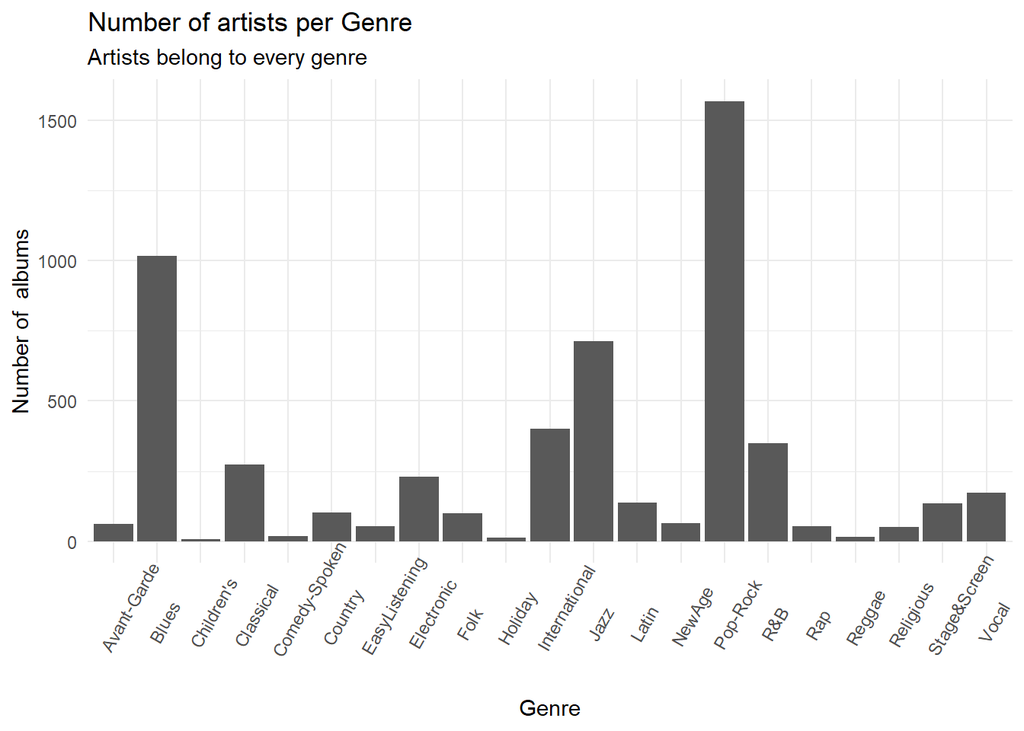

```r
plot_d <- ggplot(data=count_of_albums%>%
                   select(-Title,-Year)%>%
                   distinct()%>%
                   group_by(genre),aes(genre))+geom_bar(stat='count')+theme_minimal()+
  labs(title='Number of artists per Genre',subtitle = 'Artists belong to every genre',x='Genre',y='Number of  albums')+
  theme(axis.text.x = element_text(angle = 60, vjust = 0.5, hjust=0.2))

plot_d
```

### [2]Δώστε την κατανομή των album ανά χρονιά

```r
year <- albums%>%
  group_by(Year)%>%
  summarize(count=n())%>%
  arrange(desc(count))
year
```

```
## # A tibble: 74 × 2
##    Year  count
##    <chr> <int>
##  1 1998    318
##  2 1994    311
##  3 2005    305
##  4 1999    302
##  5 2003    300
##  6 2012    300
##  7 2002    291
##  8 1991    289
##  9 1997    287
## 10 2013    285
## # … with 64 more rows
```

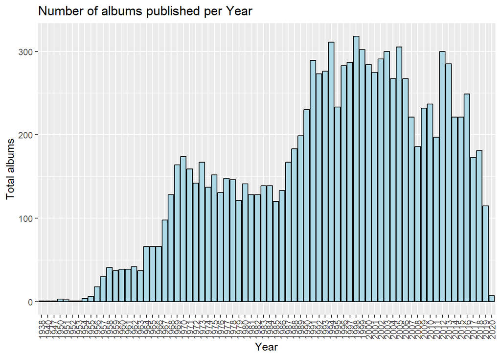

```r
#visualize
library(ggplot2)
year_plot <- ggplot(albums,aes(x=Year))+geom_bar(color='black',fill='lightblue')+
  labs(title='Number of albums published per Year',x='Year',y='Total albums')+
  theme(axis.text.x = element_text(angle = 90, vjust = 0.5, hjust=1))
year_plot
```

### [3]Δώστε τις κατανομές των album των top 5 genre στο χρόνο (στο γράφημα να φαίνονται τα genre με διαφορετικά χρώματα).

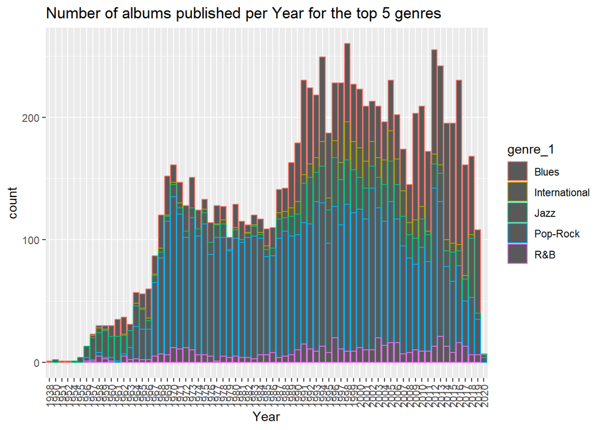

```r
#Στο συγκεκριμένο ερώτημα θεωρούμε ως genre  του album το πρωτεύον genre του artist.

year_genre_top5 <- albums%>%
  filter(genre_1 %in% top_five_genres$Var1)%>%
  select(Year,Title,genre_1)
year_genre_top5_plot <- ggplot(year_genre_top5,aes(x=Year))+geom_bar(aes(color=genre_1))+
  labs(title='Number of albums published per Year for the top 5 genres')+
  theme(axis.text.x = element_text(angle = 90, vjust = 0.5, hjust=1))
year_genre_top5_plot
```

### [4]μελετήστε τις σχέσεις ανάμεσα στα genres, δηλαδή ποια ζεύγη έχουν υψηλή συσχέτιση. Ας εστιάσουμε μόνο στο πρωτεύον και δευτερεύον genre των artist

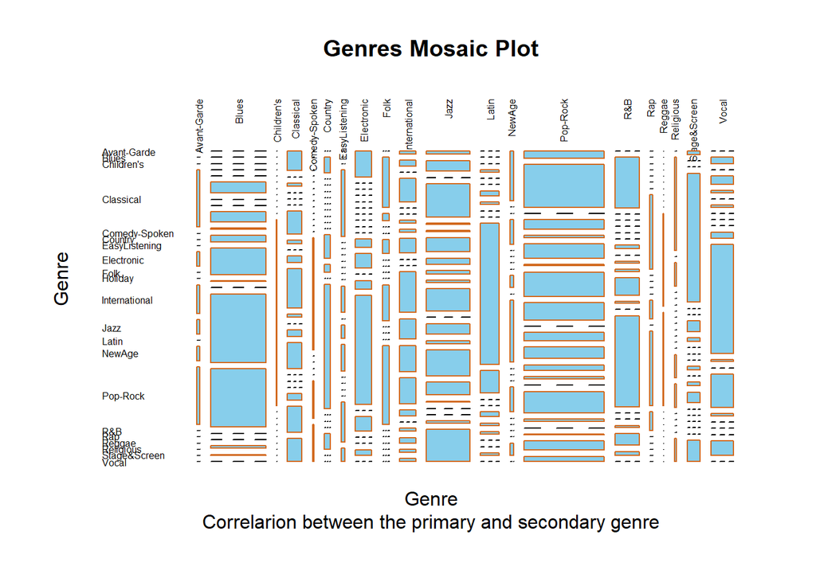

```r
# create artist dataframe
artists<- albums %>%
  select(-Title,-Year,-genre_3,-genre_4,-genre_5)%>%
  distinct_all()
artists$genre_2[is.na(artists$genre_2)]<-artists$genre_1[is.na(artists$genre_2)]

#we observe that now we have a df with 3694 artists.(instead of 3692)

artists_2<- artists%>%
  select(-artist)%>%
  filter(genre_1 != genre_2)

table_artists <- table(artists_2$genre_1,artists_2$genre_2)


mosaicplot(table_artists, main='Genres Mosaic Plot',
           sub='Correlarion between the primary and secondary genre',
           xlab='Genre',
           ylab='Genre',
           color='skyblue',
           border='chocolate',
           cex.axis = .5,
           dir=c('v','h'),
           las=2)
```

### [5] Χρησιμοποιήστε το dataset world από τη βιβλιοθήκη spData. Πάρτε τα ονόματα των χωρών και για κάθε χώρα βρείτε ποιοι τίτλοι album την περιέχουν. Προσθέστε αυτή την πληροφορία σε μια νέα στήλη για το κάθε album. Αν στον τίτλο ενός album υπάρχουν πάνω από μια χώρες, κρατήστε μόνο μια (οποιαδήποτε). Προχωρήστε στην παραγωγή χωροπληθικού χάρτη για την οπτικοποίηση του πλήθους των album ανά χώρα (δείτε σχετικά κεφάλαια του βιβλίου “Geocomputation with R”)

```r
library(spData)
library(sf)
world <- world
world
```

```
## Simple feature collection with 177 features and 10 fields
## Geometry type: MULTIPOLYGON
## Dimension:     XY
## Bounding box:  xmin: -180 ymin: -89.9 xmax: 180 ymax: 83.64513
## Geodetic CRS:  WGS 84
## # A tibble: 177 × 11
##    iso_a2 name_l…¹ conti…² regio…³ subre…⁴ type  area_…⁵     pop lifeExp gdpPe…⁶
##  * <chr>  <chr>    <chr>   <chr>   <chr>   <chr>   <dbl>   <dbl>   <dbl>   <dbl>
##  1 FJ     Fiji     Oceania Oceania Melane… Sove…  1.93e4  8.86e5    70.0   8222.
##  2 TZ     Tanzania Africa  Africa  Easter… Sove…  9.33e5  5.22e7    64.2   2402.
##  3 EH     Western… Africa  Africa  Northe… Inde…  9.63e4 NA         NA       NA
##  4 CA     Canada   North … Americ… Northe… Sove…  1.00e7  3.55e7    82.0  43079.
##  5 US     United … North … Americ… Northe… Coun…  9.51e6  3.19e8    78.8  51922.
##  6 KZ     Kazakhs… Asia    Asia    Centra… Sove…  2.73e6  1.73e7    71.6  23587.
##  7 UZ     Uzbekis… Asia    Asia    Centra… Sove…  4.61e5  3.08e7    71.0   5371.
##  8 PG     Papua N… Oceania Oceania Melane… Sove…  4.65e5  7.76e6    65.2   3709.
##  9 ID     Indones… Asia    Asia    South-… Sove…  1.82e6  2.55e8    68.9  10003.
## 10 AR     Argenti… South … Americ… South … Sove…  2.78e6  4.30e7    76.3  18798.
## # … with 167 more rows, 1 more variable: geom <MULTIPOLYGON [°]>, and
## #   abbreviated variable names ¹name_long, ²continent, ³region_un, ⁴subregion,
## #   ⁵area_km2, ⁶gdpPercap
```

```r
class(world)
```

```
## [1] "sf"         "tbl_df"     "tbl"        "data.frame"
```

```r
countries_names <- world$name_long

x <- sapply(countries_names, function(x) grepl(paste0("\\b",x,"\\b"),albums$Title))

# Define a function to check if a row has at least one true value
has_true <- function(y) {
  if (any(y)) {
    return(colnames(x)[which(y)])
  } else {
    return(NA)
  }
}

# Apply the function to each row of the matrix
country_in_the_Title <- apply(x, 1, has_true)

#create a new column in albums with the name of the country the title includes
albums_final <- cbind(albums,country_in_the_Title)
country_in_the_Title <- as.data.frame(country_in_the_Title)
country_in_the_Title <- country_in_the_Title%>%
  na.omit()%>%
  group_by(country_in_the_Title)%>%
  summarise(count=n())
colnames(country_in_the_Title)<- c('name_long','count')
# Load dplyr package
library(dplyr)
library(tmap)
# Using dplyr - left join multiple columns
country_final <- country_in_the_Title  %>% merge(world[,'name_long'],
                             by='name_long')

country_final <- st_as_sf(country_final)
class(country_final)
```

```
## [1] "sf"         "data.frame"
```

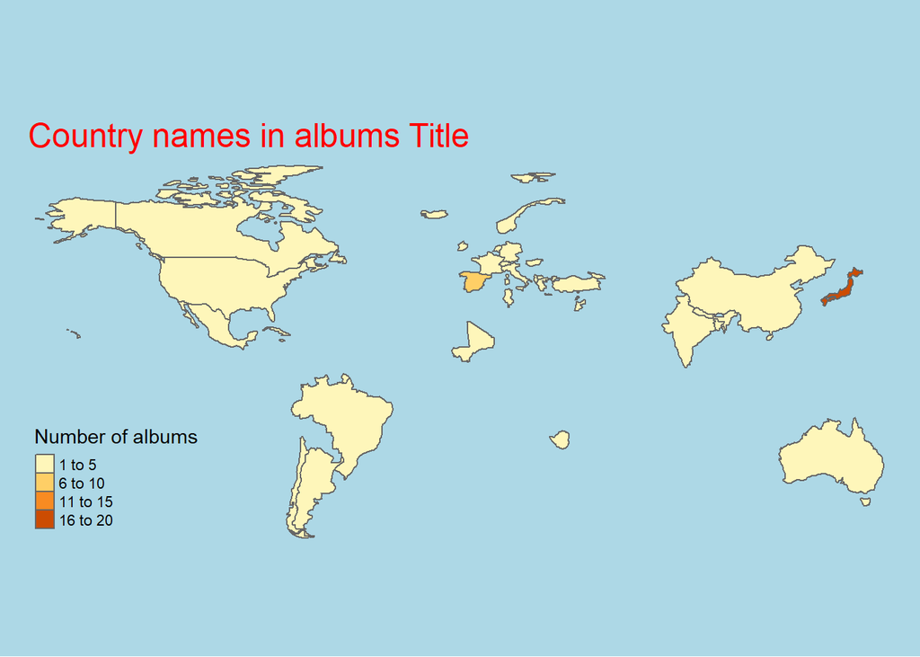

```r
tmap_options(bg.color='lightblue')
tm_shape(country_final)+tm_polygons('count',pallette='div',title='Number of albums')+
  tm_layout(frame=FALSE,main.title= 'Country names in albums Title',main.title.color ='red')
```

## [6] Δώστε τρείς επιπλέον δικές σας ενδιαφέρουσες οπτικοποιήσεις των δεδομένων.

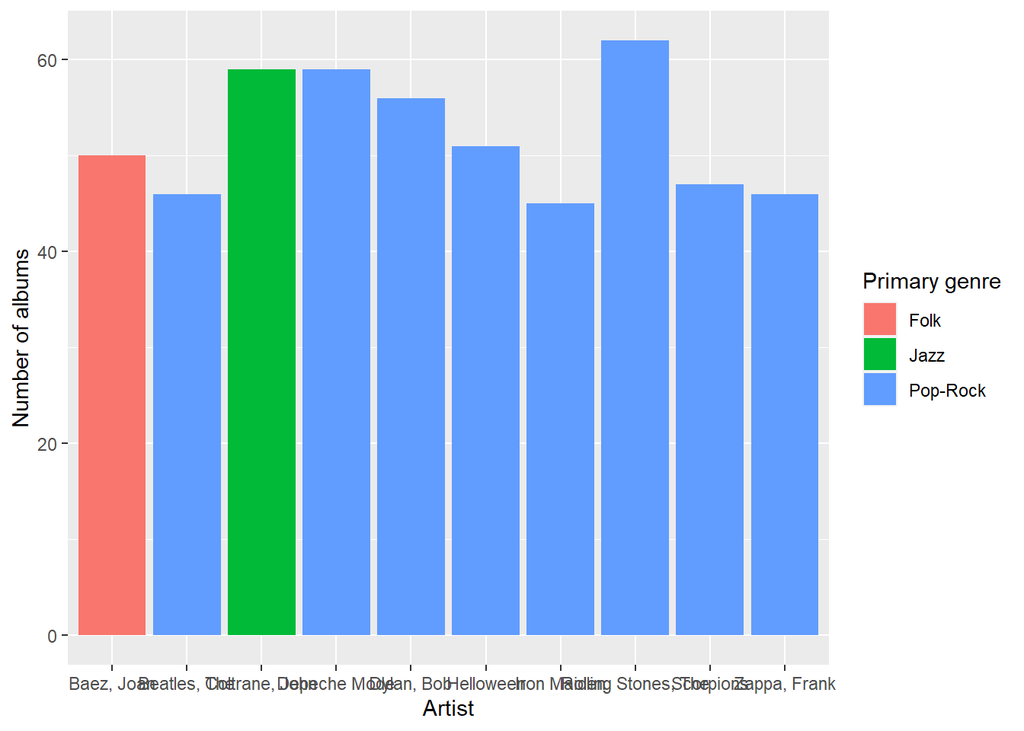

```r
artists_with_most_albums <- albums %>%
  select(artist,Title,genre_1)%>%
  group_by(artist)%>%
  summarize(num_of_albums= n())%>%
  arrange(desc(num_of_albums))%>%
  slice(1:10)

artists_with_most_albums_final<- merge(x=artists_with_most_albums,y=albums, by='artist',all.x = TRUE)%>%
  select(artist,num_of_albums,genre_1)%>%
  distinct()


artists_with_most_albums_final %>% ggplot(aes(x= factor(artist),y=num_of_albums,fill=genre_1))+
  geom_bar(stat='identity')+
  labs(x='Artist',y='Number of albums')+ guides(fill=guide_legend(title="Primary genre"))
```

```r
#we observe the 10 artists with most albums published and we see that 8 of them are from the Pop-rock scene.
```

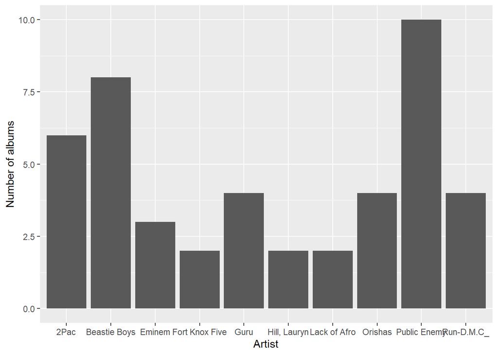

```r
artists_with_most_albums_rap <- albums %>%
  filter(genre_1 == 'Rap')%>%
  select(artist,Title)%>%
  group_by(artist)%>%
  summarize(num_of_albums= n())%>%
  arrange(desc(num_of_albums))%>%
  slice(1:10)

artists_with_most_albums_rap  %>% ggplot(aes(x= factor(artist),y=num_of_albums))+
  geom_bar(stat='identity')+
  labs(x='Artist',y='Number of albums')
```

```r
#here is Tupac
```